# KD Practicum 4.1

## Graphical summaries (optional)

### A layered grammar of graphics

Practicum 4.1 opens an optional chapter in KD by outlying the principles of Wilkinson, Anand, and Grossman (2005)[^1] that underlie the grammar of graphics in R — implemented within the **ggplot2** library.

The practicum will outline the basics of grammar of graphics, which is a paradigm that enables to concisely describe the components of a graphic. This approach allows us to move beyond named graphics (e.g., the “scatterplot”) and gain insight into the deep structure that underlies statistical graphics.

The process of creating layered graphics in R is rather complex and encapsulates the following tasks:

- Canvas initialization: during this phase stands global coordinate system is initialized after the `ggplot2()` wrapper is called. At this stage, global variables are specified by user withing aesthetic function `aes()`.
- Layer definition: plots are build by superimposing graphical components. These can be defined using **geom**, **stats** and **scales** functions.
  - **Geom** functions are used to build common plots such as histograms, scatterplots, line plots, etc. Different geoms types exist for representing *data points*, whilst *variables* are supplied to geom’s aesthetic properties.
  - **Stats** are functions that commonly used to build new variables to plot (e.g., count, prop). You can also fit regression spline to your data using ggplot embedded stats functions alone.
  - **Scales** map data values to the visual values of anaesthetic. Use for associating color, type, size to different levels of factors, for example.
- ggplot2 objects can be saved into file or printed on screen only one at a time. To overcome this hurdle, we will use **cowplot package**[^2] that provides the function `plot_grid()` to arrange plots into a grid and label them. Cowplot also allows you to combine ggplot graphics with other R objects, such as tibbles.

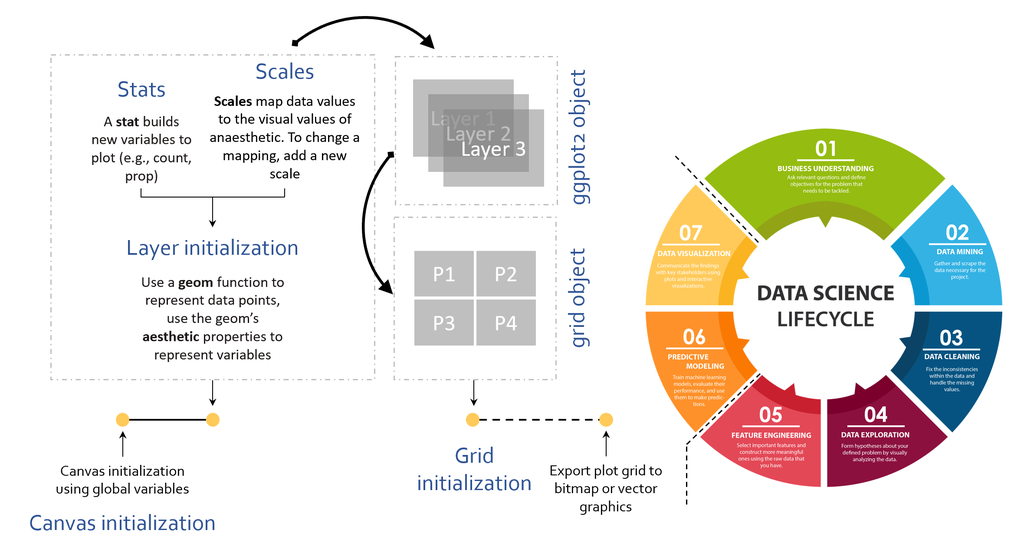

### Data description

```r
ggplot2::mpg %>% head(n=3)
```

```
## # A tibble: 3 × 11
##   manufacturer model displ  year   cyl trans      drv     cty   hwy fl    class
##   <chr>        <chr> <dbl> <int> <int> <chr>      <chr> <int> <int> <chr> <chr>
## 1 audi         a4      1.8  1999     4 auto(l5)   f        18    29 p     compa…
## 2 audi         a4      1.8  1999     4 manual(m5) f        21    29 p     compa…
## 3 audi         a4      2    2008     4 manual(m6) f        20    31 p     compa…
```

### Hypothesis formulation

Let’s use our first graph to answer a question: do cars with big engines use more fuel than cars with small engines? You probably already have an answer, but try to make your answer precise. What does the relationship between engine size and fuel efficiency look like? Is it positive? Negative? Linear? Nonlinear?

You can test your answer with the mpg data frame found in ggplot2 (aka ggplot2::mpg). Among the variables in *mpg* that should interest you are:

- **displ:** displacement, a car’s engine size in *liters*.
- **hwy:** a car’s fuel efficiency on the highway, in *miles per gallon* (mpg). A car with a low fuel efficiency consumes more fuel than a car with a high fuel efficiency when they travel the same distance.

### Devil’s first touches

We can visualize the relation between the engine displacement and fuel consumption by putting the first variable on the x-axis and the second variable on the y-axis.

In addition, we will inspect distributions and central tendencies for each variable using box plots. Once generated, we will append them to the scatter plot using the `plot_grid()` function, which is implemented in the cowplot package.

We begin each plot with the function **`ggplot()`**. `ggplot()` creates a canvas, i.e. a coordinate system onto layers are added.

The first argument of `ggplot()` is the dataset to use in the graph. So `ggplot(data = mpg)` creates an empty graph which will use mpg’s columns as global variables. Then, the `geom_point()` function will add **a layer** **of points** to create a scatter plot.

Each **geom** function can take **a mapping argument**. This defines how variables in your dataset are mapped to visual properties. The mapping argument is always paired with **`aes()`**, and the **x** and **y** arguments of **`aes()`** specify which variables to map to the x and y-axes. ggplot2 looks for the mapped variable in the data argument, in this case, mpg.

Once created, every plot is associated with left hand operator `<-` to its name that is accessible from global environment.

[figure not shown]

```r
library(cowplot)
theme_set(theme_bw() +
            theme(panel.grid.major = element_blank(),
                  panel.grid.minor = element_blank()))

p1 <- ggplot(data = mpg) +
  geom_point(mapping = aes(x = displ, y = hwy), colour="steelblue") +
  ggtitle("KPG vs. Displacement")

p2 <- ggplot(data = mpg) +
  geom_boxplot(outlier.colour="black",
               outlier.shape=16, outlier.size=2,
               notch=T, aes(y = displ)) +
  ggtitle("Displacement")

p3 <- ggplot(data = mpg) +
  geom_boxplot(outlier.colour="steelblue",
               outlier.shape=16, outlier.size=2,
               notch=T, aes(y = hwy,)) +
  ggtitle("Kilometers per gallon")

plot_grid(p1, p2, p3, labels = c('A', 'B', 'C'), label_size = 12)
```

The plot shows a negative relationship between engine size (displ) and fuel efficiency (hwy), meaning that cars with big engines use more fuel.

### Scaling and aesthetics

Say, one group of points seems to fall outside of the linear trend. These cars have a higher mileage than you might expect. How can you explain these cars? Let’s hypothesize that the cars are hybrids. One way to test this hypothesis is to look at the class value for each car.

You can add a **third variable**, like class, to a two-dimensional scatter plot by mapping it to an **aesthetic**. An aesthetic is a visual property of the objects in your plot. Aesthetics include things like the *size*, the *shape*, **opacity** (alpha), or the *color* of your points.

To map an aesthetic to a variable, associate the name of the aesthetic to the name of the variable inside **aes()**. ggplot2 will automatically assign a unique level of the aesthetic (here a unique color) to each unique value of the variable, a process known as scaling.

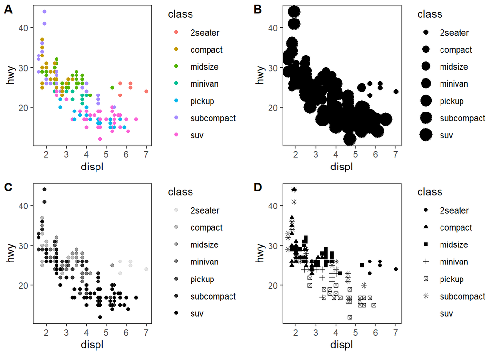

```r
p1 <- ggplot(data = mpg) +
  geom_point(mapping = aes(x = displ, y = hwy, color = class))

p2 <- ggplot(data = mpg) +
  geom_point(mapping = aes(x = displ, y = hwy, size = class))

p3 <- ggplot(data = mpg) +
  geom_point(mapping = aes(x = displ, y = hwy, alpha = class))

p4 <- ggplot(data = mpg) +
  geom_point(mapping = aes(x = displ, y = hwy, shape = class))

plot_grid(p1, p2, p3, p4, labels = c('A', 'B', 'C', 'D'), label_size = 12)
```

### Geom objects

A geom is the geometrical object that a plot uses to represent data. People often describe plots by the type of geom that the plot uses. For example, bar charts use bar geoms, line charts use line geoms, boxplots use boxplot geoms, and so on. Scatterplots break the trend; they use the point geom.

Every geom function in ggplot2 takes a mapping argument. However, not every aesthetic works with every geom. On the other hand, you could set the linetype of a line. `geom_smooth()` will draw a different line, with a different linetype, for each unique value of the variable that you map to line type:

`ggplot(data = mpg) + geom_smooth(mapping = aes(x = displ, y = hwy, linetype = drv))`

To display multiple geoms in the same plot, add multiple geom functions to ggplot():

`ggplot(data = mpg) + geom_point(mapping = aes(x = displ, y = hwy, color = class)) + geom_smooth(mapping = aes(x = displ, y = hwy))`

This, however, introduces some duplication in our code. Imagine if you wanted to change the y-axis to display cty instead of hwy. You’d need to change the variable in two places, and you might forget to update one.

You can avoid this type of repetition by **passing a set of mappings to ggplot()**. ggplot2 will treat these mappings as global mappings that apply to each geom in the graph.

### Adding regression lines/splines

Once global variables are set, you can use them to generate several overlaying plots. For example, we are interested in fitting and plotting multiple regression models to the same data, whist avoiding copying R code. To this end, we will use the `geom_smooth()` function which will contain formula for the regression model we want to fit.

Note that **geom_smooth() and stat_smooth() are effectively aliases**: they both use the same arguments. Use `stat_smooth()` if you want to display the results with a non-standard geom.

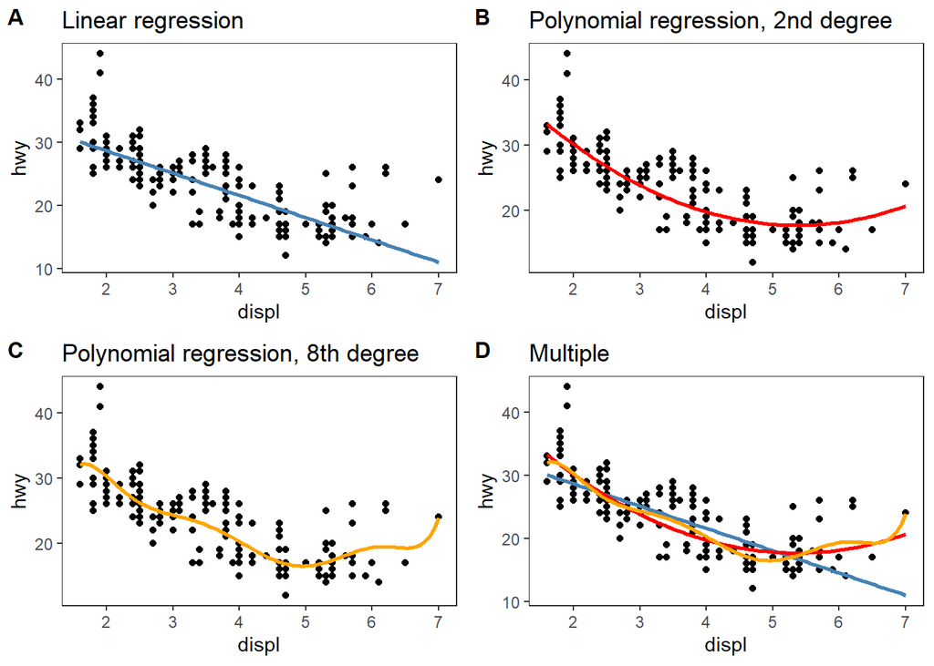

```r
p1 <- ggplot(data = mpg, aes(x = displ, y = hwy)) +
  geom_point() +
  geom_smooth(method = "lm", se = FALSE, color = "steelblue") +
  ggtitle("Linear regression")

p2 <- ggplot(data = mpg, aes(x = displ, y = hwy)) +
  geom_point() +
  stat_smooth(method="lm", se=TRUE, fill=NA,
              formula=y ~ poly(x, 2, raw=FALSE),colour="red") +
  ggtitle("Polynomial regression, 2nd degree")

p3 <- ggplot(data = mpg, aes(x = displ, y = hwy)) +
  geom_point() +
  stat_smooth(method="lm", se=TRUE, fill=NA,
              formula=y ~ poly(x, 8, raw=FALSE),colour="orange") +
  ggtitle("Polynomial regression, 8th degree")

p4 <- ggplot(data = mpg, aes(x = displ, y = hwy)) +
  geom_point() +
  geom_smooth(method = "lm", se = FALSE, color = "steelblue") +
  stat_smooth(method="lm", se=TRUE, fill=NA,
              formula=y ~ poly(x, 2, raw=FALSE),colour="red") +
  stat_smooth(method="lm", se=TRUE, fill=NA,
              formula=y ~ poly(x, 8, raw=FALSE),colour="orange") +
  ggtitle("Multiple")


plot_grid(p1, p2, p3, p4, labels = c('A', 'B', 'C', 'D'), label_size = 12)
```

### References

[^1]: L. Wilkinson, A. Anand and R. Grossman, “Graph-theoretic scagnostics,” IEEE Symposium on Information Visualization, 2005. INFOVIS 2005., Minneapolis, MN, USA, 2005, pp. 157-164, doi: 10.1109/INFVIS.2005.1532142.
[^2]: https://wilkelab.org/cowplot/index.html